# Chapter 3: Environmental and Social Determinants of Cognitive Health in Puente Piedra, Peru

Gabrielle Husted

2026-06-19

## 0.1 Download Historical Purple Air Data via Data Download Tool

Sensor history: https://api.purpleair.com/#api-sensors-get-sensor-history

Fields: pm10.0_atm_a,pm10.0_atm_b,pm10.0_atm,voc_a,voc_b,voc,humidity,humidity_a,humidity_b, temperature,temperature_a,temperature_b,pm2.5_atm_a,pm2.5_atm_b,pm2.5_atm

Date range: 22-01-01 to 26-01-10

1-month average

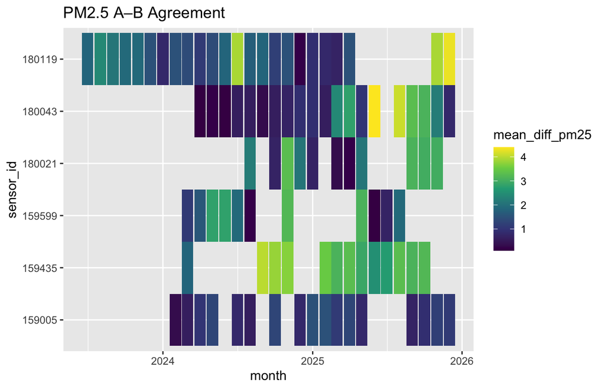

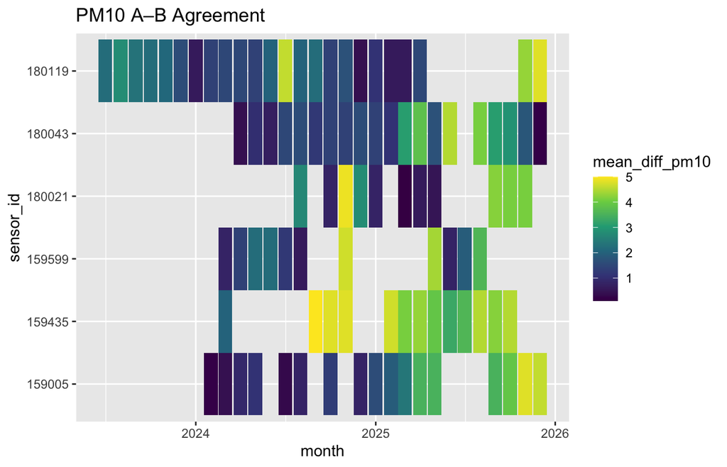

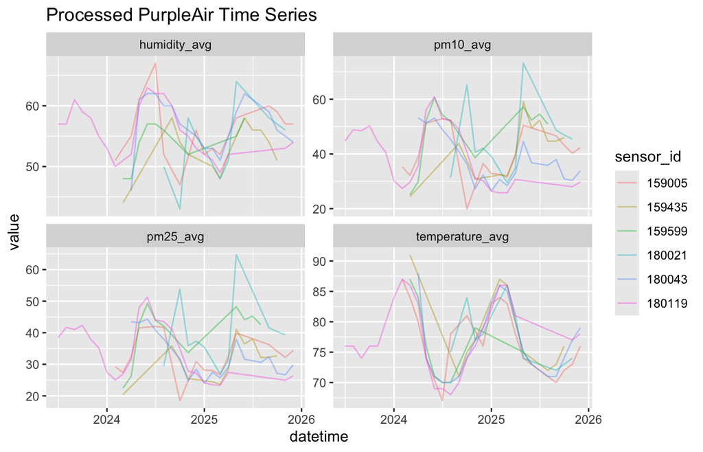

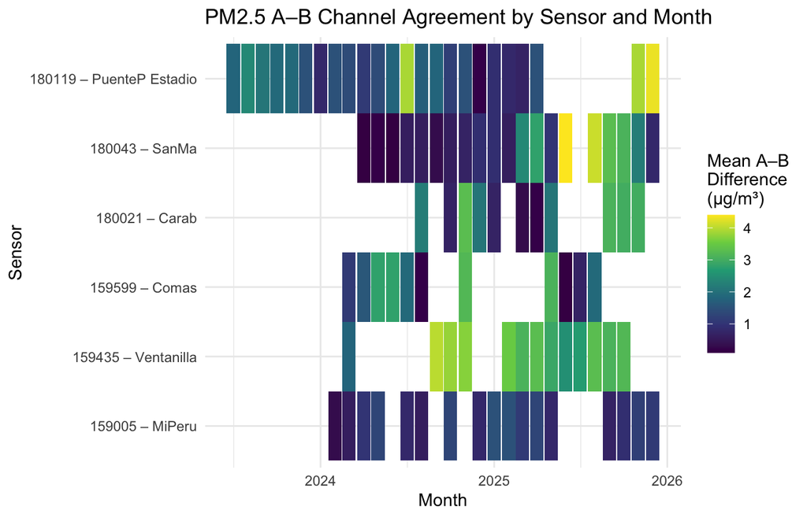

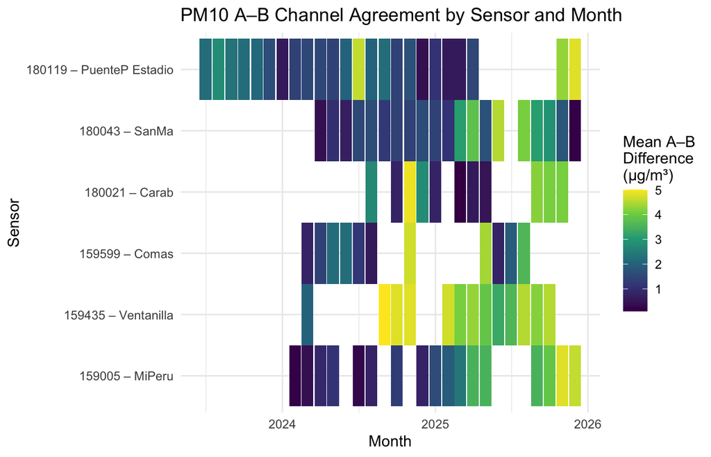

## 0.2 Visualizations: Processed Exposure Time Series

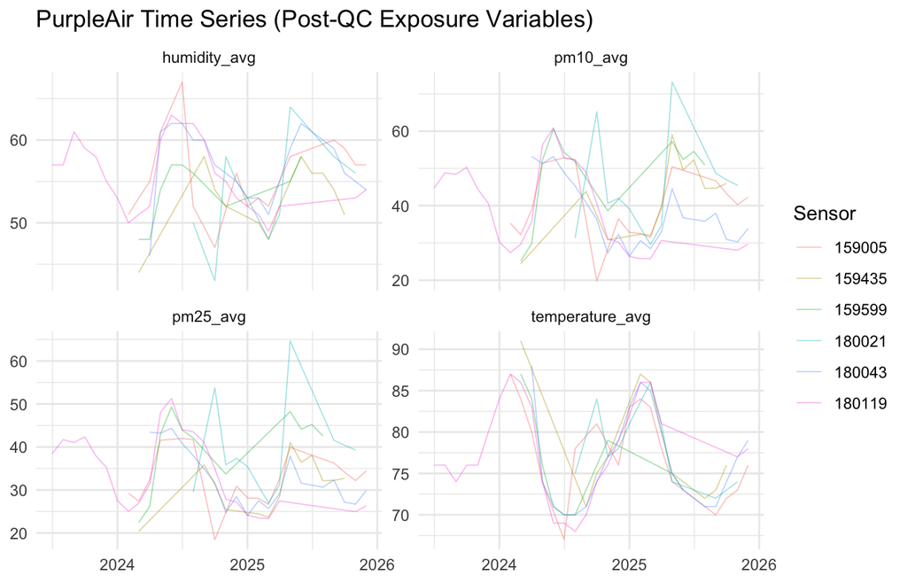

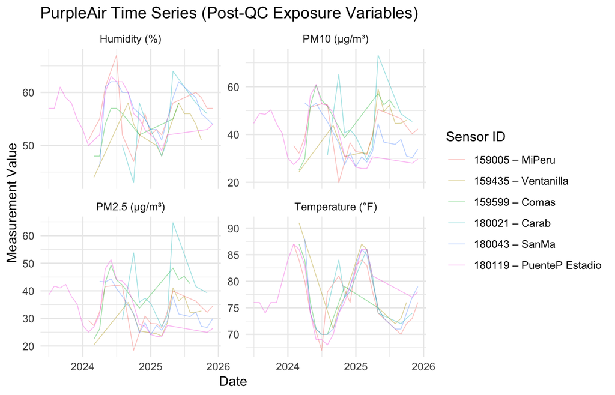

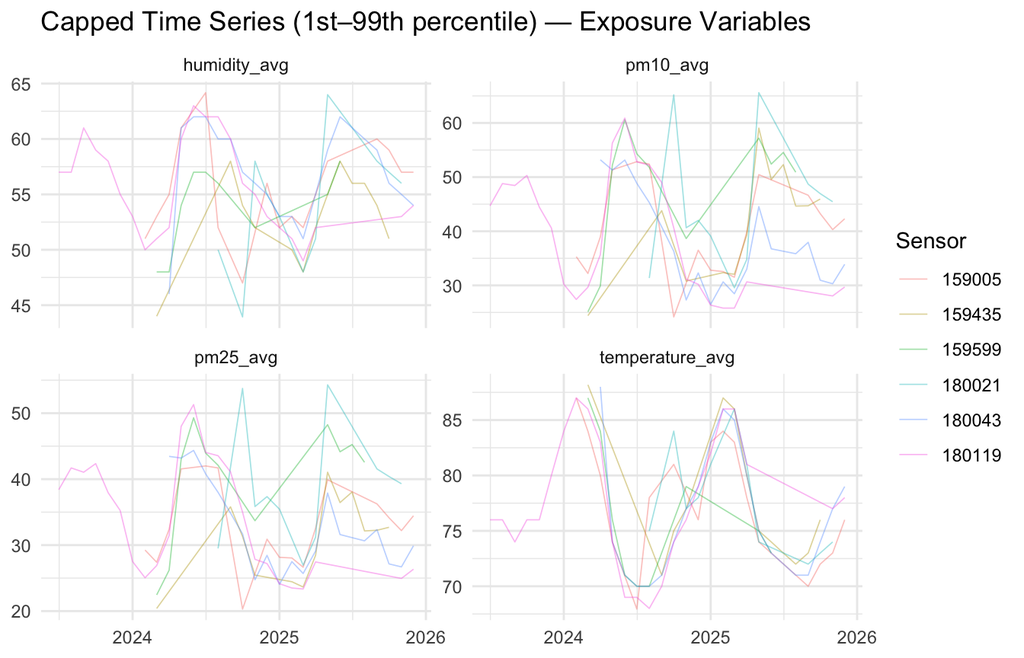

```
## # A tibble: 4 × 9
##   variable             n  mean    sd median   p25   p75   min   max
##   <chr>            <int> <dbl> <dbl>  <dbl> <dbl> <dbl> <dbl> <dbl>
## 1 Humidity (%)         6  54.8 1.46    54.7  53.8  55.6  52.9  56.8
## 2 PM10 (µg/m³)         6  41.9 3.89    40.6  39.4  44.2  37.9  48.0
## 3 PM2.5 (µg/m³)        6  35.0 3.89    33.3  32.6  38.2  30.9  40.1
## 4 Temperature (°F)     6  77.2 0.889   77.7  76.7  77.7  75.7  77.8
```

## 0.3 Adding location of sensor

Unable to get this via the data download tool, need to use the API directly

```
##
## FALSE
##     6
```

```
## # A tibble: 6 × 11
##   sensor_id mean_pm25 mean_pm10 mean_humidity mean_temperature abs_thresh
##   <fct>         <dbl>     <dbl>         <dbl>            <dbl>      <dbl>
## 1 159005         32.7      39.9          55.6             77.6          5
## 2 159435         30.9      41.3          52.9             77.7          5
## 3 159599         40.1      48.0          53.8             75.7          5
## 4 180021         39.6      45.2          53.9             77.7          5
## 5 180043         32.6      37.9          56.8             76.4          5
## 6 180119         34.0      39.2          55.6             77.8          5
## # ℹ 5 more variables: rel_thresh <dbl>, sensor_id_clean <dbl>,
## #   sensor_name <chr>, latitude <dbl>, longitude <dbl>
```

```
## Deleting source `/Users/gabriellebenoit/Documents/GitHub/peru_air/purpleair__all_sensors.gpkg' using driver `GPKG'
## Writing layer `purpleair__all_sensors' to data source
##   `/Users/gabriellebenoit/Documents/GitHub/peru_air/purpleair__all_sensors.gpkg' using driver `GPKG'
## Writing 6 features with 2 fields and geometry type Point.
```

## 0.4 Socio-demographic Data

New map, numbered by section. [Final version of the map](https://www.google.com/maps/d/edit?mid=1ZxIT6hY4dc9rtQl3oUCLNVQoDkfRK5w&usp=sharing) includes sector 5.

Confirmed (as of March 25th, 2026) working dataset: “Base de datos (Monica)_09.16.2024_MN edits 09.19.2024 copy 3.xlsx”

## 0.5 Primary variables of interest

Cognitive scores: - ACE - RUADS - PFAQ - Dementia - Dementia AM - Dementia AJ - Dementia AJ ALT - deterioro cognitivo

Exposure-related: - pollution (pm2.5, pm10) - temperature - humidity

Geography: (account for clustering) - Distrito - Sector - Conglomerado/pin

Core standard confounders: - age - sex - education - occupation

Health-related: - bmi - glucose_cat - hypertension

Socioeconomic: - overcrowding - health_insurance - civil_stat - SES level (A - E)

```
##
## NSE E NSE D NSE C NSE B NSE A  <NA>
##    66    95   352   497    80     9
```

## 0.6 Using the google map data

```
## Raw KML rows: 1106 | Dupes: 344
## Clean KML rows: 762
```

```
## spatial_data rows: 1099
```

```
## Deleting source `/Users/gabriellebenoit/Documents/GitHub/peru_air/spatial_survey_data.gpkg' using driver `GPKG'
## Writing layer `spatial_survey_data' to data source
##   `/Users/gabriellebenoit/Documents/GitHub/peru_air/spatial_survey_data.gpkg' using driver `GPKG'
## Writing 1099 features with 28 fields and geometry type 3D Point.
```

## 0.7 Spatial Join for All Variables

```
## Simple feature collection with 6 features and 6 fields
## Geometry type: POINT
## Dimension:     XYZ
## Bounding box:  xmin: 271508.3 ymin: 8689420 xmax: 271626.9 ymax: 8689480
## z_range:       zmin: 0 zmax: 0
## Projected CRS: WGS 84 / UTM zone 18S
##   conglomerado_chr         nearest_sensor_name exposure_pm25 exposure_pm10
## 1              407 GEOHealth_MiPeru_Chavinillo      32.70588      39.94412
## 2              407 GEOHealth_MiPeru_Chavinillo      32.70588      39.94412
## 3              409 GEOHealth_MiPeru_Chavinillo      32.70588      39.94412
## 4              409 GEOHealth_MiPeru_Chavinillo      32.70588      39.94412
## 5              409 GEOHealth_MiPeru_Chavinillo      32.70588      39.94412
## 6              409 GEOHealth_MiPeru_Chavinillo      32.70588      39.94412
##   exposure_temp exposure_humidity                     geometry
## 1      77.64706          55.58824 POINT Z (271508.3 8689480 0)
## 2      77.64706          55.58824 POINT Z (271508.3 8689480 0)
## 3      77.64706          55.58824 POINT Z (271626.9 8689420 0)
## 4      77.64706          55.58824 POINT Z (271626.9 8689420 0)
## 5      77.64706          55.58824 POINT Z (271626.9 8689420 0)
## 6      77.64706          55.58824 POINT Z (271626.9 8689420 0)
```

```
## Simple feature collection with 1 feature and 2 fields
## Geometry type: MULTIPOINT
## Dimension:     XYZ
## Bounding box:  xmin: 268493.9 ymin: 8678543 xmax: 276035.8 ymax: 8693834
## z_range:       zmin: 0 zmax: 0
## Projected CRS: WGS 84 / UTM zone 18S
##   n_na_any_relevant_dem n_na_sensor_id                       geometry
## 1                    29              4 MULTIPOINT Z ((268493.9 869...
```

```
## Simple feature collection with 4 features and 4 fields (with 4 geometries empty)
## Geometry type: POINT
## Dimension:     XYZ
## Bounding box:  xmin: NA ymin: NA xmax: NA ymax: NA
## z_range:       zmin: NA zmax: NA
## Projected CRS: WGS 84 / UTM zone 18S
##                     any_relevant_dem nearest_sensor_id conglomerado_chr
## 1 DC severo sin compromiso funcional                NA             1139
## 2                      Sin DC severo                NA             1035
## 3                      Sin DC severo                NA              281
## 4                      Sin DC severo                NA               78
##   conglomerado      geometry
## 1         1139 POINT Z EMPTY
## 2         1035 POINT Z EMPTY
## 3          281 POINT Z EMPTY
## 4           78 POINT Z EMPTY
```

```
## Deleting source `/Users/gabriellebenoit/Documents/GitHub/peru_air/spatial_data_final.gpkg' using driver `GPKG'
## Writing layer `spatial_data_final' to data source
##   `/Users/gabriellebenoit/Documents/GitHub/peru_air/spatial_data_final.gpkg' using driver `GPKG'
## Writing 1066 features with 34 fields and geometry type 3D Point.
```

## 0.8 Explore which sensors were used, how many participants were assigned to it

Limitations: exposure assignment was constrained to 6 sensors, with the majority of participants assigned to just 2 sensors — which reduces spatial variability in exposure estimates.

# 1 Load Data

```
##   nearest_sensor_id          nearest_sensor_name   n
## 1            159005  GEOHealth_MiPeru_Chavinillo 501
## 2            180119  GEOHealth_PuenteP_Estadio_1 361
## 3            180043        GEOHealth_SanMa_IE005 127
## 4            159599   GeoHealth_Comas_2055PAbril  54
## 5            159435 GEOHealth_Ventanilla_NSBelen  19
## 6            180021 GEOHealth_Carab_VictorRaulHT   4
```

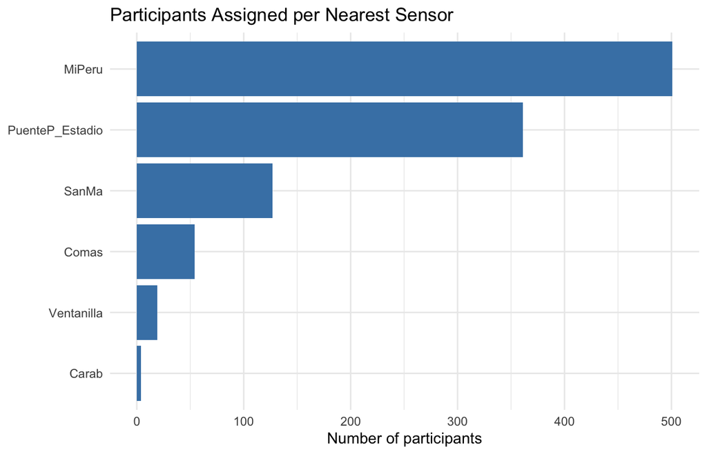

## 1.1 Examine contextual variables – clean

```
##    Var1 Freq
## 1     0   54
## 2     1   16
## 3    10   31
## 4    11  308
## 5    12   54
## 6    13   42
## 7    14   83
## 8  14.5    1
## 9    15   19
## 10   16   48
## 11   17    4
## 12   18    5
## 13   19    5
## 14    2   24
## 15   20    1
## 16   23    1
## 17    3   34
## 18    4   21
## 19    5   48
## 20    6  154
## 21    7   23
## 22    8   28
## 23    9   62
## 24 <NA>    0
```

```
##
##                         0   1
##   none                 38  16
##   primary             218  79
##   secondary_or_higher 651  64
```

```
##      civil_stat   n
## 1   Conviviente 355
## 2     Casado(a) 320
## 3    Soltero(a) 217
## 4      Viudo(a)  80
## 5   Separado(a)  75
## 6 Divorciado(a)  18
## 7          <NA>   1
```

```
##          occupation   n
## 1    Amo(a) de casa 358
## 2  Auto-empleado(a) 252
## 3 Sin empleo actual 177
## 4       Empleado(a) 165
## 5       Jubilado(a)  64
## 6         Freelance  47
## 7        Estudiante   2
## 8              <NA>   1
```

```
##
##         partnered            single separated_widowed              <NA>
##               675               217               173                 1
```

```
##
##     employed    homemaker not_employed         <NA>
##          464          358          243            1
```

```
##
## --- education_cat ---
##
##                         0   1
##   none                 38  16
##   primary             215  79
##   secondary_or_higher 649  63
##
## --- civil_stat_cat ---
##
##                       0   1
##   partnered         567 106
##   single            182  33
##   separated_widowed 153  19
##
## --- occupation_cat ---
##
##                  0   1
##   employed     406  55
##   homemaker    281  77
##   not_employed 215  26
##
## --- htn ---
##
##                         0   1
##   HTA diastólica       48  10
##   HTA sistodiastólica 105  20
##   HTA sistólica        82   6
##   Sin hipertensión    667 122
##
## --- native_lang ---
##
##                      0   1
##   Castellano       740 104
##   Quechua o aimara 162  54
##
## --- health_ins ---
##
##                                    0   1
##   Entidad prestadora de salud      7   1
##   Essalud                        205  18
##   Fuerzas armadas o policiales    25   0
##   No está afiliado               126  26
##   No sabe                         18  11
##   Seguro integral de salud (SIS) 505 101
##   Seguro privado de salud         16   1
##
## --- chronic_dis ---
##
##        0   1
##   No 557 106
##   Sí 345  52
##
## --- sex ---
##
##               0   1
##   Femenino  606 136
##   Masculino 296  22
```

```
##
##               0   1
##   SIS       507 102
##   Essalud   206  18
##   uninsured 128  26
##   other      66  13
```

```
##
##                         0   1
##   HTA diastólica       48  10
##   HTA sistodiastólica 105  20
##   HTA sistólica        82   6
##   Sin hipertensión    667 122
```

```
##
##                  0   1
##   none         668 123
##   hypertension 238  36
```

```
## [1] "numeric"
```

```
##    Min. 1st Qu.  Median    Mean 3rd Qu.    Max.    NA's
##   15.82   25.48   28.23   28.81   31.25   51.85       5
```

```
## [1] "character"
```

```
##    Length     Class      Mode
##      1066 character character
```

```
##
## NSE E NSE D NSE C NSE B NSE A  <NA>
##    60    93   339   487    78     9
```

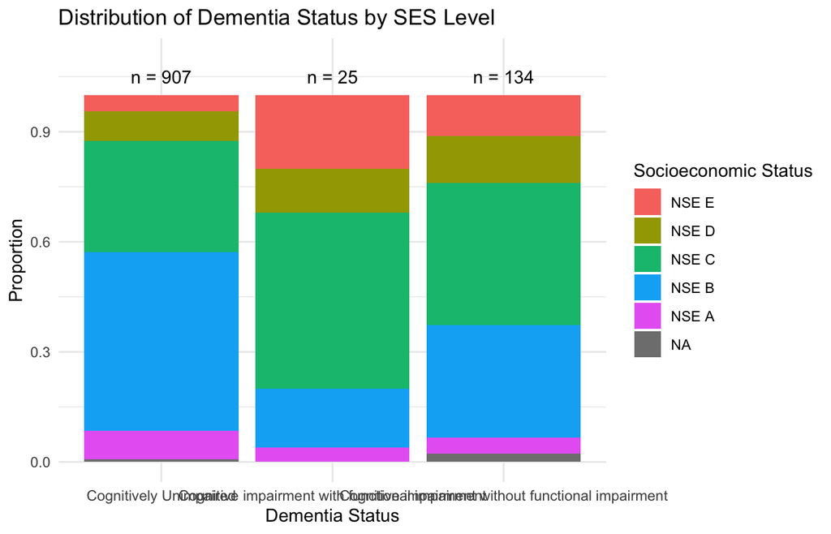

## 1.2 Check missingness

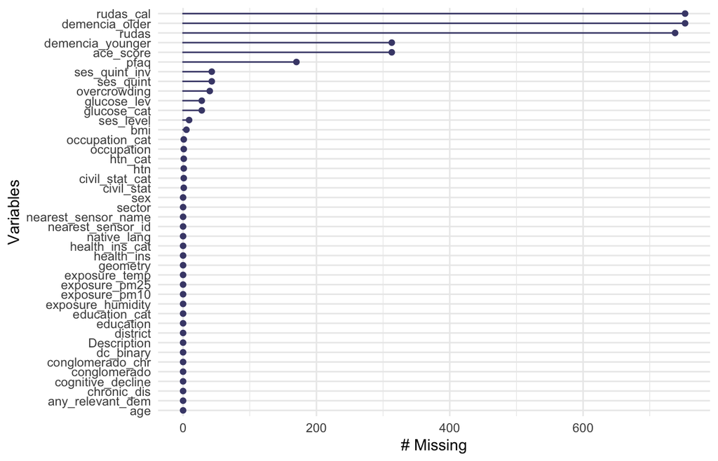

```
##
##   0   1
## 907 159
```

```
## [1] 1033
```

```
##   exposure_pm25   n
## 1      30.93462  19
## 2      32.60750 127
## 3      32.70588 501
## 4      33.97500 361
## 5      39.63182   4
## 6      40.08182  54
```

## 1.3 Create standardized versions of PM 2.5, PM 10, temperature, and humidity

# and quartile for PM 2.5

# Interpretation: SD models: OR = dementia odds per 1 SD increase in exposure Quartile models: OR = dementia odds relative to lowest exposure group

```
## [1] "numeric"
```

## 1.4 Descriptive Exploration

```
## # A tibble: 2 × 6
##   dc_binary     n pm25_mean pm25_sd pm10_mean pm10_sd
##       <dbl> <int>     <dbl>   <dbl>     <dbl>   <dbl>
## 1         0   907      33.5    1.75      39.9    2.08
## 2         1   159      33.4    1.48      39.7    1.72
```

# boxplots # pm 2.5

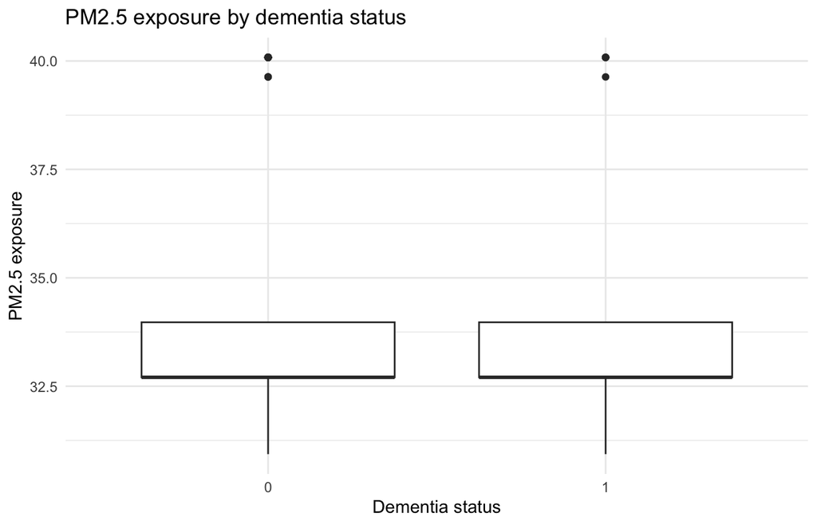

# 2 pm 10

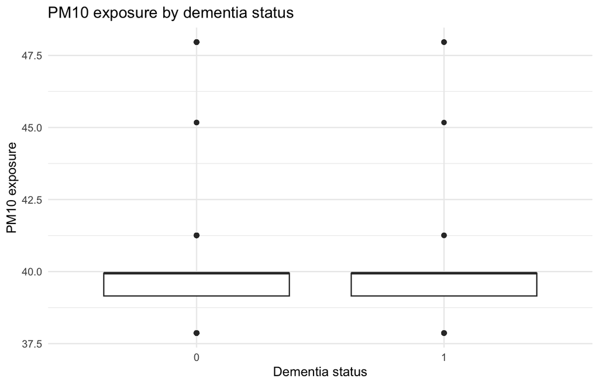

## 2.1 Analysis (Thursday, April 9)

1. dc_binary or any_relevant_dem as primary outcome
2. stratified analyses for older and younger adults with their continuous scores as secondary outcome

# determine how many NAs there are for any_relevant dementia, dc_binary, rudas, ace, pfaq # how do they or do they not overlap?

```
## na_per_row
##   0   1   2   3
## 197 540 306  23
```

```
## any_relevant_dem        dc_binary            rudas        ace_score
##                0                0              738              313
##             pfaq         geometry
##              170                0
```

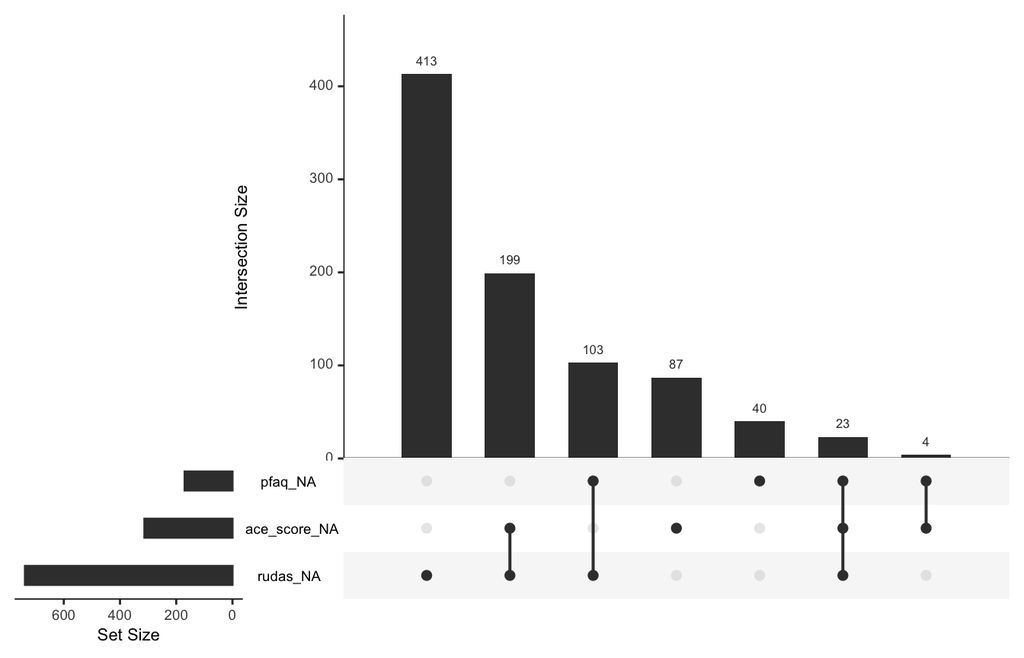

## Delete observations that are missing all five variables because they need at least one of those measures to be able to be in our analyses meaningfully.

```
## [1] 1066
```

```
##   n_rudas n_ace n_pfaq n_dc
## 1     328   753    896 1066
```

```
## # A tibble: 4 × 4
##   took_rudas took_ace mean_age     n
##   <lgl>      <lgl>       <dbl> <int>
## 1 FALSE      FALSE        69.4   222
## 2 FALSE      TRUE         43.1   516
## 3 TRUE       FALSE        69.3    91
## 4 TRUE       TRUE         43.2   237
```

```
## # A tibble: 2 × 5
##   took_ace min_age max_age mean_age     n
##   <lgl>      <dbl>   <dbl>    <dbl> <int>
## 1 FALSE         60      95     69.4   313
## 2 TRUE          30      59     43.1   753
```

## 2.2 Primary analysis: full sample

```
## dc_binary ~ exposure + age + sex
```

## 2.3 Secondary analysis: older adults (60+)

```
## as.numeric(rudas) ~ exposure + age + sex
```

## 2.4 Secondary analysis: younger adults (30-59):

```
## as.numeric(ace_score) ~ exposure + age + sex
```

## 2.5 Create the age groups:

## 2.6 Prep

## 2.7 How many unique conglomerados per sector?

```
## # A tibble: 5 × 2
##   sector   n_conglomerados
##   <chr>              <int>
## 1 Sector 5             230
## 2 Sector 3             203
## 3 Sector 1             172
## 4 Sector 4             167
## 5 Sector 2             165
```

# Confirm cluster counts

```
## [1] 684
```

```
## [1] 5
```

Our data is such that administrative codes are not equal to spatial units. Many conglomerados values appear in multiple sectors. Some appear in 2 sectors. Some appear in 3 or 4 (e.g. 128,409, 480)… conglomerado is NOT globally unique.

We have this hierarchy: -District: Puente Piedra -Sector (5 levels) -Conglomerado (reused within district, overlaps across sectors).. a local code system, not a globally unique cluster ID

Requires TWO-WAY clustering or a composite ID derives from sector + conglomerado

## 2.8 Create Unique spatial cluster ID

## 2.9 Standardize exposures

## 2.10 Tidy: unified cluster robust model function

## 2.11 Models

# Exposures

# Binary

# Rudas

# ACE

## 2.12 Combine everything

## 2.13 Susie Table (Full model results)

Supplementary Table. Full model results — all covariates

| Outcome | Exposure | Model | Covariate | β / OR | 95% CI | p-value |
| --- | --- | --- | --- | --- | --- | --- |
| ACE | Humidity | Age & sex adjusted | Humidity (per SD) | -0.07 | (-0.85, 0.71) | 0.858 |
|  |  |  | Age | -0.28 | (-0.37, -0.19) | <0.001 |
|  |  |  | Sex (Male) | 3.82 | (2.18, 5.47) | <0.001 |
|  |  | Fully adjusted | Humidity (per SD) | -0.27 | (-0.97, 0.42) | 0.443 |
|  |  |  | Age | -0.16 | (-0.25, -0.07) | <0.001 |
|  |  |  | Sex (Male) | 1.23 | (-0.55, 3.01) | 0.176 |
|  |  |  | SES: NSE D | 1.14 | (-3.77, 6.04) | 0.65 |
|  |  |  | SES: NSE C | 3.61 | (0.05, 7.18) | 0.047 |
|  |  |  | SES: NSE B | 6.72 | (3.28, 10.16) | <0.001 |
|  |  |  | SES: NSE A (Highest) | 7.57 | (3.67, 11.47) | <0.001 |
|  |  |  | bmi | -0.02 | (-0.16, 0.11) | 0.733 |
|  |  |  | Education: Primary | 18.07 | (8.71, 27.43) | <0.001 |
|  |  |  | Education: Secondary+ | 27.39 | (18.19, 36.6) | <0.001 |
|  |  |  | civil_stat_catsingle | 0.13 | (-1.58, 1.84) | 0.879 |
|  |  |  | civil_stat_catseparated_widowed | 0.30 | (-2.14, 2.74) | 0.811 |
|  |  |  | occupation_cathomemaker | -1.11 | (-2.77, 0.56) | 0.194 |
|  |  |  | occupation_catnot_employed | -0.91 | (-3.49, 1.67) | 0.492 |
|  |  |  | Hypertension | -2.16 | (-4.11, -0.21) | 0.03 |
|  |  |  | glucose_catPrediabetes | -0.10 | (-1.83, 1.63) | 0.906 |
|  |  |  | glucose_catDiabetes | 0.52 | (-1.48, 2.53) | 0.609 |
|  |  |  | Chronic Disease | 0.88 | (-0.66, 2.43) | 0.262 |
|  |  | Unadjusted | Humidity (per SD) | -0.13 | (-0.94, 0.68) | 0.757 |
|  | PM10 | Age & sex adjusted | PM10 (per SD) | -0.05 | (-0.84, 0.74) | 0.91 |
|  |  |  | Age | -0.28 | (-0.37, -0.19) | <0.001 |
|  |  |  | Sex (Male) | 3.82 | (2.18, 5.47) | <0.001 |
|  |  | Fully adjusted | PM10 (per SD) | 0.17 | (-0.55, 0.89) | 0.647 |
|  |  |  | Age | -0.16 | (-0.25, -0.07) | <0.001 |
|  |  |  | Sex (Male) | 1.23 | (-0.55, 3) | 0.177 |
|  |  |  | SES: NSE D | 1.11 | (-3.79, 6.01) | 0.657 |
|  |  |  | SES: NSE C | 3.60 | (0.04, 7.16) | 0.048 |

[output cut: 234 more lines]

## 2.14 Forest Plot

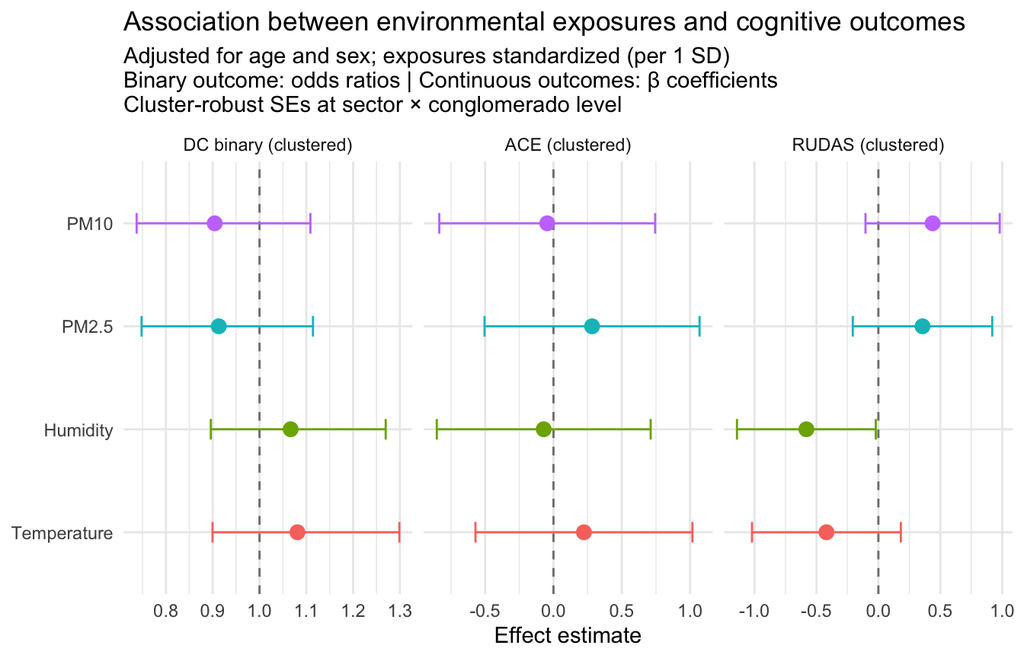